# Homework_4_Iyer_Krithika_EM

Krithika Iyer

1 May 2018

### Problem Statement

#### 1.Prediction of energy consumption of appliances by using Bayesian Logistic Regression

##### **DATASET**: Appliances energy prediction Data Set - by University of Mons

##### **FEATURES** : The data set consisted of 27 features which were the number of appliances,humidity and temperature data collected at various points in a house and several other features.

##### **ALGORITHM** : The value to be predicted is a non-negative integer value. Hence the regression method selected was “POISSON REGRESSION”. To estimate the hyperparameters of the regression equation Hamilton Monte Carlo(HMC) sampling method was used.

#### **ANALYSIS:**

**(1) POISSON DISTRIBUTION :**
$$P(y=k|\lambda) = \frac{exp(-\lambda) (\lambda)^k} {k!}\hspace{20pt} for\hspace{4pt} k = (0,\infty)$$
$$E[y] = \lambda \hspace{10pt} (mean)$$
**(2) PARAMETERIZATION FOR REGRESSION :**

y - count variable

$x_i$ , i = 1 to N K-dimensional feature vector for N training data

Parameterize :
$$\lambda = h(x_i) \gneq 0$$
$$\lambda = H({x_i}^T \beta) \gneq 0$$
Where $\beta$ are the hyperparameters which are to be estimated.
$${x_i}^T \beta --> maps--> \mathbb{R}^K --> \mathbb{R}$$
$$H(.) --> maps--> \mathbb{R} --> [0,\infty)$$
$$\lambda = exp({x_i}^T \beta)$$

**(3) EQUATION OF DISTRIBUTION FOR REGRESSION :**
$$P(y=y_k | x_i,\beta ) = \frac{exp[-exp({x_i}^T \beta)] [exp({x_i}^T \beta)]^{y_k}}{y_k!}$$
Where, y - N x 1 matrix,

$x_i$ - N x (K+1) matrix (One extra column of 1’s has to be added for $\beta_0$ term)

$\beta$ = (K+1) X 1 ($\beta_0,\beta_1.....\beta_K$)

**(4) POSTERIOR FOR $\beta \sim \mathcal{N}(0,\sigma^2)$**
$$p(\beta | y,x_i,\sigma^2) \propto \prod_{i=1}^ N p(y|x_i,\beta) p(\beta ;\sigma^2)$$
$$p(\beta | y,x_i,\sigma^2) \propto \prod_{i=1}^ N \frac{exp[-exp({x_i}^T \beta)] [exp({x_i}^T \beta)]^{y_k}}{y_k!}p(\beta ;\sigma^2)$$

Taking log on both sides,

$$log[p(\beta | y,x_i,\sigma^2)] \propto log[\prod_{i=1}^ N \frac{exp[-exp({x_i}^T \beta)] [exp({x_i}^T \beta)]^{y_k}}{y_k!} p(\beta ;\sigma^2)$$
$$log[p(\beta | y,x_i,\sigma^2)] \propto \sum_{i=i}^N log[\frac{exp[-exp({x_i}^T \beta)] [exp({x_i}^T \beta)]^{y_k}}{y_k!} exp(\frac{||\beta|| ^2}{2\sigma^2} )]$$
$$log[p(\beta | y,x_i,\sigma^2)] \propto \sum_{i=i}^N [-exp({x_i}^T \beta)+ y_k {x_i}^T \beta +\frac{||\beta|| ^2}{2\sigma^2} - log(y_k !) ]$$

Comparing with the equation :
$$p(\beta/y;x,\sigma) \propto exp(- \mathcal{U}(\beta))$$
We get,
$$\mathcal{U}(\beta) = \sum_{i=i}^N [exp({x_i}^T \beta) - y_k {x_i}^T \beta - \frac{||\beta|| ^2}{2\sigma^2} + log(y_k !) ]$$
$$\nabla \mathcal{U}(\beta) = \sum_{i=i}^N [exp({x_i}^T \beta)x_i^T - y_k {x_i}^T - \frac{||\beta||}{\sigma^2}$$
These two equations were used in the HMC code for estiamtion of parameters $\beta$s.

http://www.cs.toronto.edu/~radford/ham-mcmc-simple was used for implementation of HMC.

Various parameter combination of parameter values for the step size, number of steps and sigma were tried and none of them gave appropraite trace graphs for the the beta value. The accepatance rate although high for beta but the values either increased indefinately or decreased.

In order to tackle the problem of high magnitude values of $\nabla \mathcal{U}(\beta)$ and $\mathcal{U}\beta$ the parameterization was changed to,

$$\lambda = ({\frac{x_i^T \beta}{scale}}) ^2$$
Even with this parameterization the results were not acceptable.

After performing various experiments with parameter tuning, it can be concluded that for Poisson regression with large magnitude of feature values using HMC for sampling the beta values is not an appropriate method.Other model fitting approached would have to be adopted in order to estimate the beta parameter correctly. Kindly see the other RMD file for implementation and results.

#### 2.SEGEMENTATION FOR GRAYSCALE IMAGES USING EM FOR GMM

Segmentation is the process of partitioning a digital image into multiple segments (sets of pixels, also known as super-pixels). The goal of segmentation is to simplify and/or change the representation of an image into something that is more meaningful and easier to analyze.Image segmentation is typically used to locate objects and boundaries (lines, curves, etc.) in images. More precisely, image segmentation is the process of assigning a label to every pixel in an image such that pixels with the same label share certain characteristics.

**EXPECTATION MAXIMIZATION :**

This is a unsupervised learning setting, hence given data - ${x^{(1)},x^{(2)},x^{(3)},x^{(4)}.....x^{(n)}}$ do not come with any label.

We wish to model the data by specifying a joint distribution $p(x^{(i)},z^{(i)}) = p(x^{(i)}|z^{(i)}) p(z^{(i)})$.

Here $z^{(i)} \sim Multinomial(\pi) \hspace{10pt} \pi_j \geq 0,\sum_{j=1}^k pi_j = 1 \hspace{10pt} \pi_i \hspace{5pt} gives \hspace{5pt} p(z^{i}=j) \hspace{10pt} x^{(i)}|z^{(i)} = j \sim \mathcal{N}(\mu_j,\sum_j)$

We let $k$ denote the number of values that the $z^{(i)}$’s can take on. Thus, our model posits that each $x^{(i)}$ was generated by randomly choosing $z^{(i)}$ from ${1,...,k}$, and then $x^{(i)}$ was drawn from one of$k$Gaussians depending on $z^{(i)}$.This forms a Gaussian mixture model and the $z^{(i)}$ are latent/hidden variables which makes the problem of estimation difficult.

The parameters of our model are thus $\pi$ , $\mu$ and $\sum$. To estimate them, we can write down the likelihood of our data:

$$\mathcal{l}(\pi,\mu,\Sigma) = \sum_{i=1}^m log \hspace{3pt} p(x^{(i)};\pi,\mu,\Sigma)$$
$$\mathcal{l}(\pi,\mu,\Sigma) = \sum_{i=1}^m log \sum_{z^{(i)}=1}^k p(x^{(i)}|z^{(i)};\mu,\Sigma) p(z^{(i)};\pi)$$
Maximizing this with repect ot $\pi$ , $\mu$ and $\Sigma$ gives us the parameters-
$$\pi_j = \frac{1}{m} \sum_{i=1}^{m} 1 \{z^{(i)} =j\}$$
$$\mu_j = \frac{\sum_{i=1}^{m}1 \{z^{(i)} =j\} x^{(i)}}{\sum_{i=1}^{m}1 \{z^{(i)} =j\}}$$
$$\Sigma_j = \frac{\sum_{i=1}^{m}1 \{z^{(i)} =j\} (x^{(i)} - \mu_j)(x^{(i)} - \mu_j)^T}{\sum_{i=1}^{m}1 \{z^{(i)} =j\}}$$

If $z^{(i)}$’s are not known. Therefore EM which is an iterative algorithm is used where it tried to guess of $z^{(i)}$ in E step and in M step it updates the parameters of the model based on the guess.

**ALGORITHM :** Repeat until convergence {

*1.E STEP* For each i,j,set

$$w_j^{(i)} := p(z^{(i)} = j | x^{(i)} ;\pi,\mu,\Sigma)$$
Here $\tau_j$ is the weight associated with the distribution.
$$w_j^{(i)} := \frac{\tau_j \mathcal{f}(x^{(i)} ;\pi_j,\mu_j,\Sigma_j)} {\sum_{k = 1}^{K} \tau_k \mathcal{f}(x^{(i)} ;\pi_k,\mu_k,\Sigma_k)}$$
*2. M STEP* Update parameters:

$$\pi_j := \frac{1}{m} \sum_{i=1}^{m} w_j^{(i)}$$
$$\mu_j = \frac{\sum_{i=1}^{m} w_j^{(i)} x^{(i)}}{\sum_{i=1}^{m} w_j^{(i)}}$$
$$\Sigma_j := \frac{\sum_{i=1}^{m} w_j^{(i)} (x^{(i)}-\mu_j)(x^{(i)}-\mu_j)^T}{\sum_{i=1}^{m} w_j^{(i)}}$$

} The code used for reference is from the author : Prof. Jose Vicente Manjon Herrera [5]

For image segementation, histogram of the image is taken as the dsitribution p(x). It is smoothned to a Gaussina by convolving it with a filter [1 2 3 2 1].

Each intensity present in the histogram image can belong to any of the K Gaussians .

As per the EM algorithm the update equations are used and the clusters are assigned to each pixel in the histogram and finally the image is restored with the Gaussian number it belongs to.

```r
library(png)
library(R.basic)
library(pracma)
library(RgoogleMaps)
```

```r
## Reads a PNG image (as a simple matrix), which for some reason needs to be
## transposed and flipped to be displayed correctly
read.image = function(filename)
{
  y = readPNG(filename)
  y = RGB2GRAY(y)
  n = nrow(y)
  ## transpose and flip image
  y= t(y)[,n:1]
  y = round(256*y)
  return(y)
}

## Displays an image
display.image = function(x, col=gray(seq(0,1,1/256)))
{
  w = dim(x)[1]
  h = dim(x)[2]
  par(mai = c(0,0,0,0))
  image(x, asp=h/w, col=col)
}
```

```r
histogram = function(img)
{
  img = as.matrix(img[is.nan(img)==FALSE])
  img = as.matrix(img[is.infinite(img)==FALSE])

  im_size = length(img)

  max_intensity = ceiling(max(img))+1;
  im_hist = matrix(0,1,max_intensity)
  for(i in 1:im_size)
  {
   pix_int = floor(img[i])
   if(pix_int>0 && pix_int<(max_intensity-1))
   {
     a2 = img[i]-pix_int
     a1 = 1- a2
     im_hist[pix_int] = im_hist[pix_int] + a1
     im_hist[pix_int+1] = im_hist[pix_int+1] + a2
   }
  }

im_hist = convolve(im_hist,rev(c(1,2,3,2,1)),type='open')
im_hist = im_hist[3:(length(im_hist)-2)]
im_hist = im_hist/sum(im_hist)
return(im_hist)
}
```

This function calculates $w_j$

```r
E_weights = function(img,wts,sigma2,mu,k)
{
  dist = matrix(0,(nrow(img)*ncol(img)),k)
  img = as.matrix(as.vector(img))

  for(i in 1:k)
  {

    exponent = img-mu[i]
    norm_cons = wts[i]/sqrt(2*pi*sigma2[i])
    dist[,i] = norm_cons * exp(-0.5*exponent*exponent/sigma2[i])

  }
  return(dist)
}
```

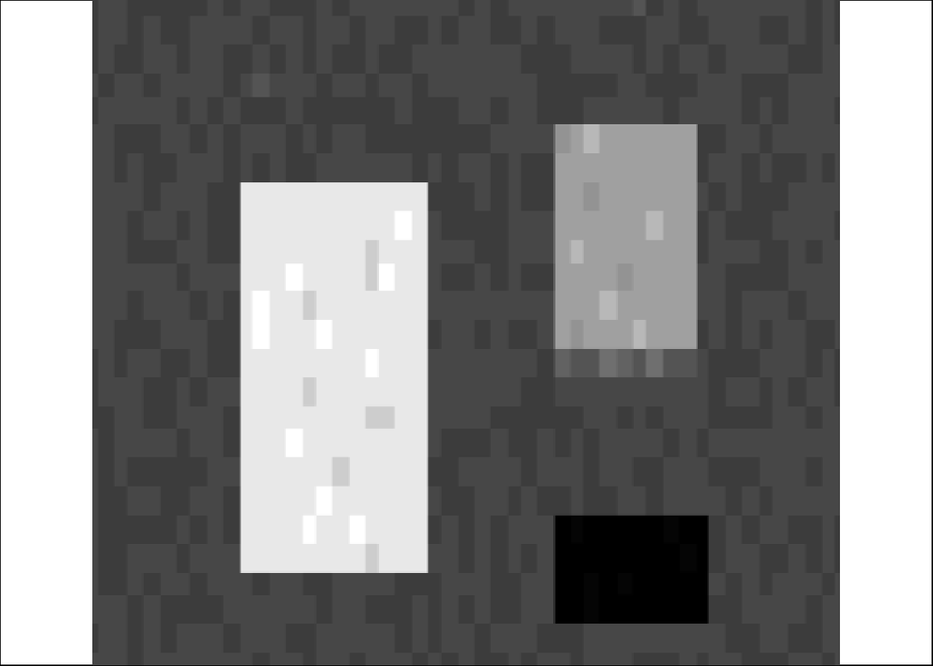

```r
setwd('C:\\Users\\iyerk\\Documents\\University of Utah Spring 2018\\ProbabilisticModelling2018\\Project_PM');
img = read.image('CAPTURE.png')

display.image(img)
```

```r
rows = nrow(img)
cols = ncol(img)
no_cluster = 4
k=no_cluster

image_copy = img
img = matrix(img,(rows*cols),1)
img_min = min(img)
img = img - img_min + 1
img_max = max(img)
s = length(img)
```

```r
im_hist = histogram(img)
non_zero_indx = which(im_hist>0)
x = as.matrix(non_zero_indx)
im_hist = im_hist[non_zero_indx]
```

```r
###INITIALIZATION
mu = (1:k)*img_max/(k+1)
wts = rep(1,k)
wts = wts/sum(wts)
sigma2 = rep(1,k)*img_max
small_var = mean(diff(x))/1000
threshold = 0.0001
eps = 2.2204e-16
```

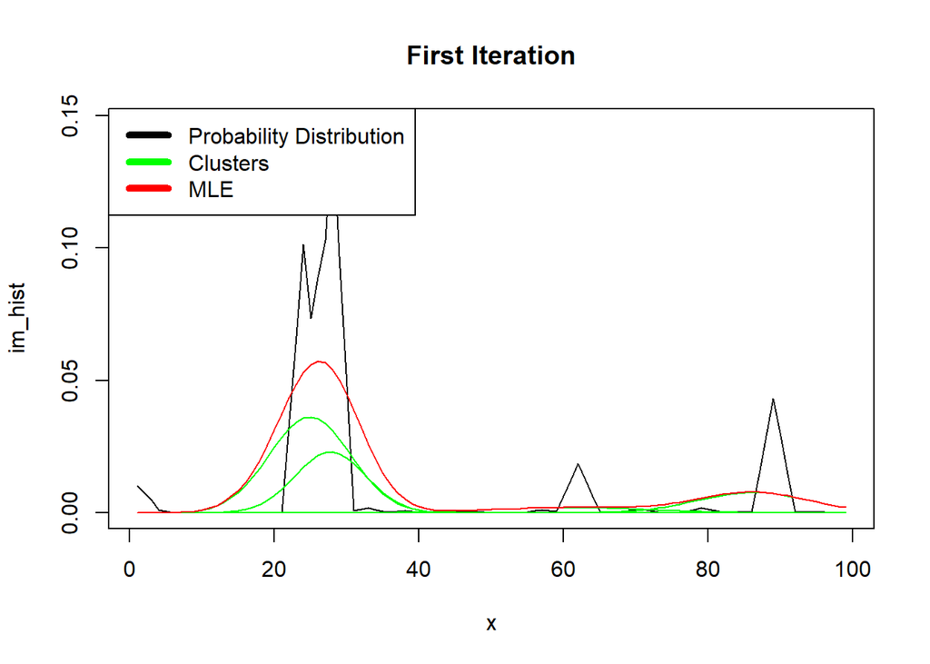

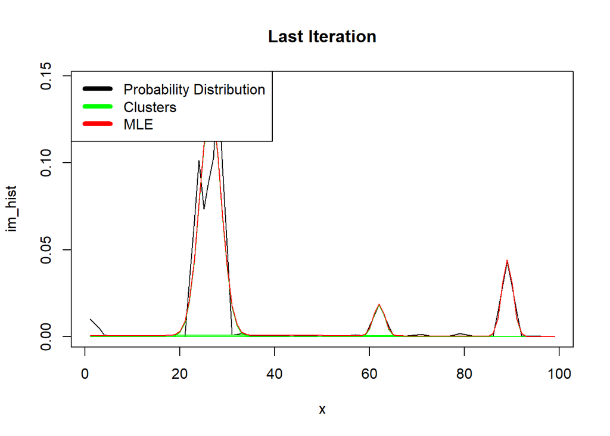

```r
iter = 1
while (1)
{

  ###E STEP
  pij = E_weights(x,wts,sigma2,mu,k)
  temp = rowSums(pij) +eps
  log_like = sum(im_hist*log(temp))

  ###M STEP
  for(class in 1:k)
  {
    normal_prob = im_hist*pij[,class] / temp
    wts[class] = sum(normal_prob)
    mu[class] = sum(x*normal_prob)/(wts[class])
    sigma2[class] = sum((x-mu[class])*(x-mu[class])*normal_prob)/(wts[class] + small_var)

  }
  wts = wts / sum(wts)
  #M STEP
  new_pij = E_weights(x,wts,sigma2,mu,k)
  temp = rowSums(new_pij) + eps
  new_log_likeli = sum(im_hist*log(temp))

  if(iter ==1)
  {
    plot(x,im_hist,'l',col='black',main="First Iteration")
  for(cl in 1:k)
  {
   lines(x,new_pij[,cl],col='green')
  }

  lines(x,rowSums(new_pij),col='red')
  legend("topleft",legend = c('Probability Distribution','Clusters','MLE'),col=c("black","green","red"),lwd = 5)
  }
   iter = iter +1

  if((new_log_likeli - log_like)<threshold)

  {
    plot(x,im_hist,'l',col='black',main = "Last Iteration")
  for(cl in 1:k)
  {
   lines(x,new_pij[,cl],col='green')
  }

  lines(x,rowSums(new_pij),col='red')
  legend("topleft",legend = c('Probability Distribution','Clusters','MLE'),col=c("black","green","red"),lwd = 5)

  break
  }


}
```

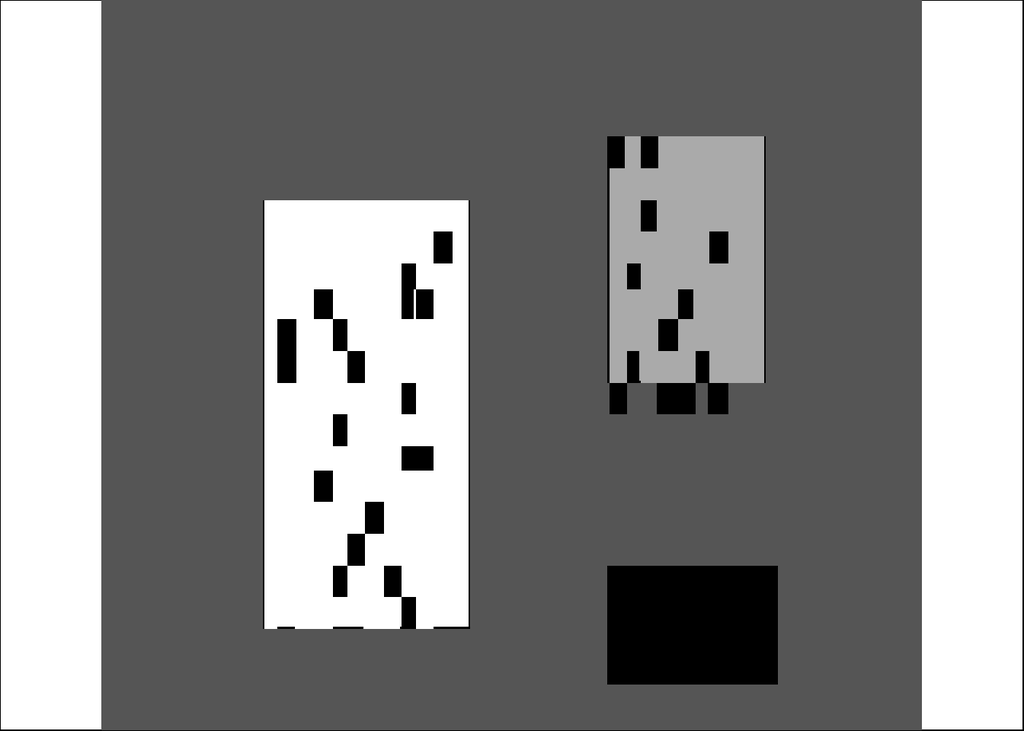

```r
mu = mu+img_min -1
img_dim = dim(image_copy)
cluster_center = matrix(0,img_dim[1],img_dim[2])
p=NULL

for(r in 1:img_dim[1])
{
  for(c in 1:img_dim[2])
  {

    p = E_weights(as.matrix(image_copy[r,c]),wts,sigma2,mu,k)

    #print(p)
    max_p = which(p ==max(p))

    cluster_center[r,c] = max_p
  }
}

display.image(20*cluster_center-10)
```

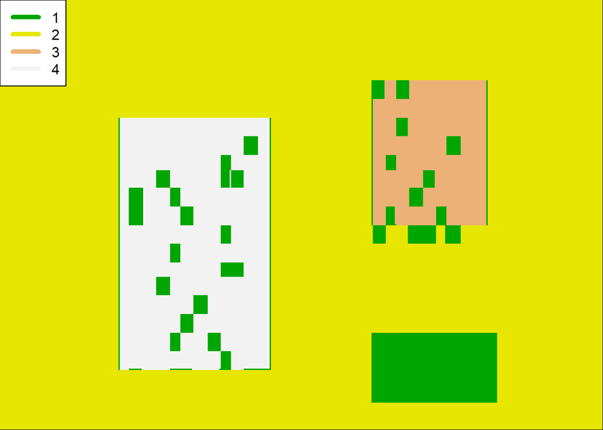

```r
image(1:img_dim[1],1:img_dim[2],cluster_center,col = terrain.colors(k))
legend("topleft",legend=c(1:k),col=terrain.colors(k),lwd = 5)
```

#### **OTHER OUTPUTS**

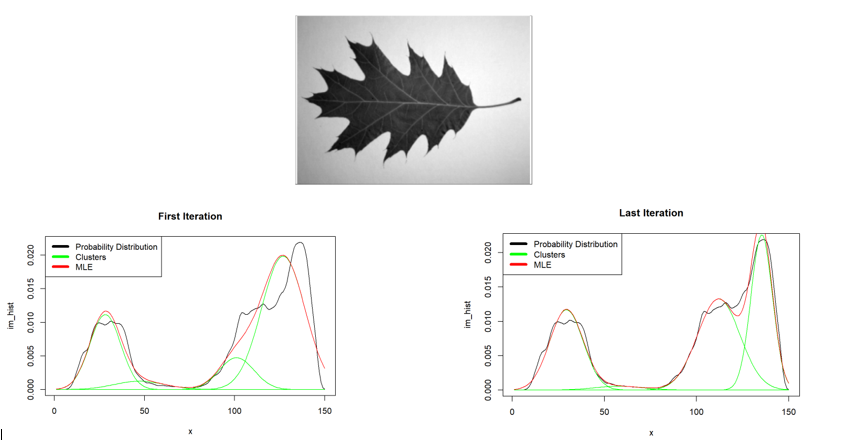

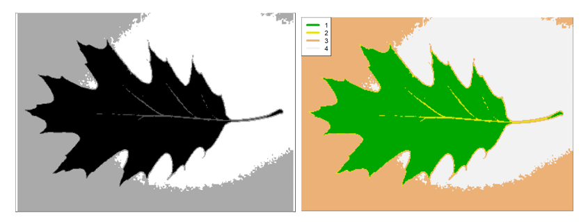

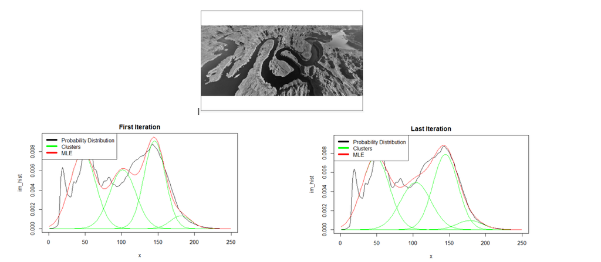

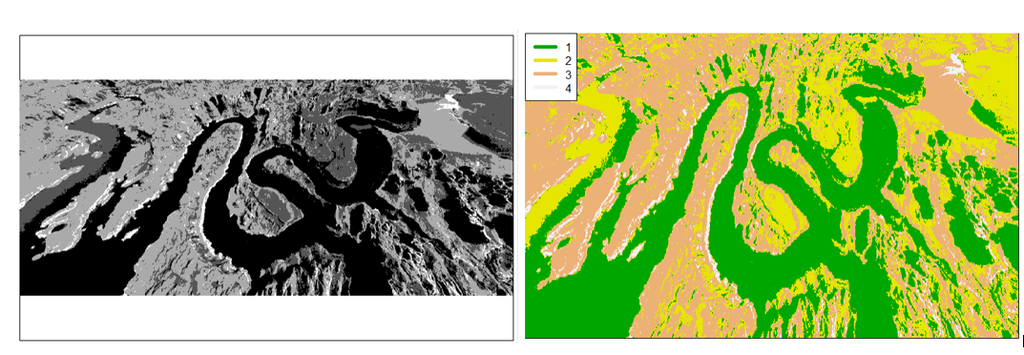

#### **REFERENCES** :

1.https://en.wikipedia.org/wiki/Image_segmentation

2.https://en.wikipedia.org/wiki/Expectation-maximization_algorithm

3.http://cs229.stanford.edu/notes/cs229-notes8.pdf

4.http://www.cs.cmu.edu/~awm/10701/assignments/EM.pdf

5.https://github.com/jeffminton/Thesis